# Module5_Monet-style Image Generation using GANs

## **David Emilio Vega Bonza, david.vegabonza@colorado.edu**

### **CC 80215162, Bogotá. Colombia**

## Introduction to Deep Learning - Week 5 Project

## **Monet-style Image Generation using GANs**

## **0. Project Topic:**

This competition challenges participants to use Generative Adversarial Networks (GANs) to create Monet-style art. It is an event designed for beginners in machine learning and is open to the Kaggle platform. Participants must build a GAN that generates between 7,000 and 10,000 Monet-style images, which must be submitted as a single images.zip file containing 256x256 pixel JPG images.

## **1. Problem Description and Data Overview**

**Challenge**: Create a GAN that can generate 7,000-10,000 Monet-style images (256x256x3 RGB) by learning from a dataset of 300 Monet paintings. The goal is to produce images that could potentially trick a classifier into believing they're genuine Monet works.

**Data Characteristics**:

- **Monet images**: 300 paintings (256x256x3) in both JPEG and TFRecord formats
- **Photo images**: 7,028 photos (256x256x3) in both JPEG and TFRecord formats
- Image dimensions: 256x256 pixels with 3 color channels (RGB)
- Data formats provided: JPEG and TFRecord (TensorFlow's efficient binary format)

## **2. Exploratory Data Analysis (EDA)**

### Import the necessary libraries and Data

```python
import numpy as np
import pandas as pd
import matplotlib.pyplot as plt
plt.style.use('Solarize_Light2')
import seaborn as sns

from sklearn.model_selection import train_test_split
from sklearn.linear_model import LogisticRegression

from sklearn import metrics
from sklearn.metrics import confusion_matrix, classification_report,accuracy_score,precision_score,recall_score,f1_score

from sklearn import tree
from sklearn.tree import DecisionTreeClassifier

from sklearn.ensemble import BaggingClassifier
from sklearn.ensemble import RandomForestClassifier

import scipy.stats as stats
from sklearn.model_selection import GridSearchCV

import tensorflow as tf
from tensorflow.keras import layers, Model, losses, optimizers
import os
import time
from glob import glob
```

[figure not shown]

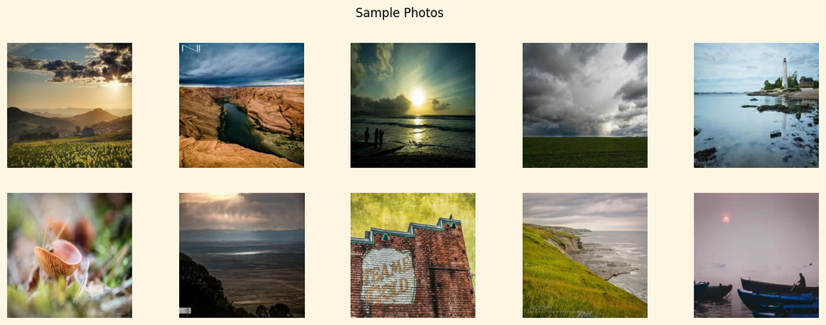

```python
# Load sample images
monet_images = glob('./data/w5/monet_jpg/*.jpg')
photo_images = glob('./data/w5/photo_jpg/*.jpg')

# Display sample images
def display_images(image_paths, title):
    plt.figure(figsize=(15, 5))
    for i in range(10):
        img = plt.imread(image_paths[i])
        plt.subplot(2, 5, i+1)
        plt.imshow(img)
        plt.axis('off')
    plt.suptitle(title)
    plt.show()

display_images(monet_images, "Sample Monet Paintings")
display_images(photo_images, "Sample Photos")
```

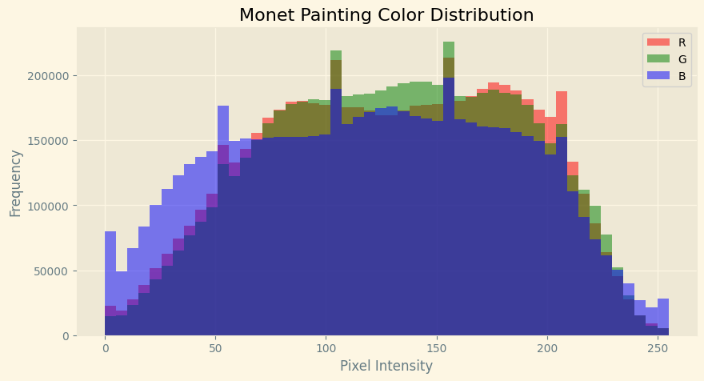

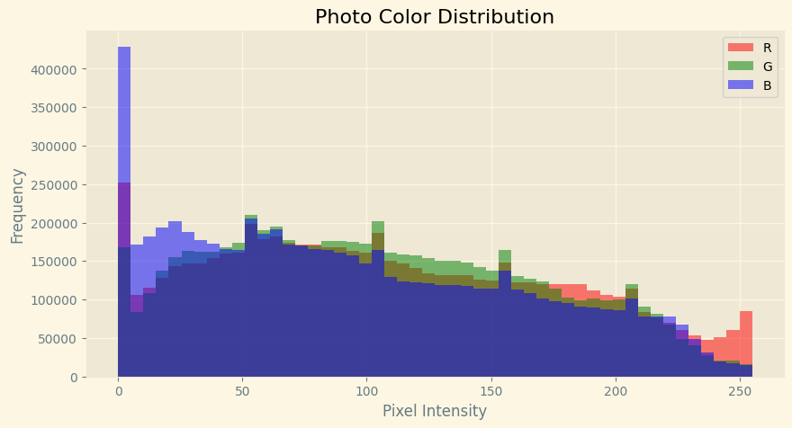

```python
# Analyze color distributions
def plot_color_histogram(image_paths, title):
    plt.figure(figsize=(10, 5))
    colors = ('r', 'g', 'b')
    for i in range(3):
        channel_values = []
        for img_path in image_paths[:100]:  # Sample 100 images for efficiency
            img = plt.imread(img_path)
            channel_values.extend(img[:, :, i].ravel())
        plt.hist(channel_values, bins=50, color=colors[i], alpha=0.5, label=colors[i].upper())
    plt.title(title)
    plt.xlabel('Pixel Intensity')
    plt.ylabel('Frequency')
    plt.legend()
    plt.show()

plot_color_histogram(monet_images, "Monet Painting Color Distribution")
plot_color_histogram(photo_images, "Photo Color Distribution")
```

**EDA Findings**:

**Analysis Plan**:

1. Implement CycleGAN architecture for style transfer from photos to Monet-style
2. Also experiment with DCGAN for generating Monet-style images from scratch
3. Use perceptual loss functions to better capture artistic style
4. Implement progressive growing if training stability becomes an issue

## **3. Model Architecture**

### GAN Fundamentals

Generative Adversarial Networks consist of:

- **Generator**: Creates fake images trying to mimic real ones
- **Discriminator**: Tries to distinguish real from fake images
- They compete in a minimax game, improving each other

### Challenges in Training GANs:

- Mode collapse (generator produces limited variety)
- Training instability (oscillations between generator/discriminator)
- Vanishing gradients

### Selected Architectures:

**1. CycleGAN** (Best for style transfer):

- Uses cycle-consistent adversarial networks
- Two generators (Monet→Photo and Photo→Monet)
- Two discriminators
- Cycle consistency loss preserves content while changing style

- Deep Convolutional GAN with transpose convolutions
- Batch normalization for stability
- LeakyReLU activations

**3. Autoencoder Component**:

- Helps the model learn efficient representations
- Encoder reduces dimensionality, decoder reconstructs
- Bottleneck layer captures essential features

```python
class CycleGAN:
    def __init__(self, img_size=256):
        self.img_size = img_size

        # Initialize generators and discriminators
        self.g_AB = self.build_generator()  # Photo → Monet
        self.g_BA = self.build_generator()  # Monet → Photo
        self.d_A = self.build_discriminator()  # Monet discriminator
        self.d_B = self.build_discriminator()  # Photo discriminator

        # Loss functions
        self.loss_fn = losses.BinaryCrossentropy(from_logits=True)
        self.l1_loss_fn = losses.MeanAbsoluteError()
        self.lambda_cycle = 10.0  # Weight for cycle consistency loss

        # Optimizers
        self.g_optimizer = optimizers.Adam(2e-4, beta_1=0.5)
        self.d_optimizer = optimizers.Adam(2e-4, beta_1=0.5)

        # Metrics
        self.g_loss_metric = tf.keras.metrics.Mean(name='g_loss')
        self.d_loss_metric = tf.keras.metrics.Mean(name='d_loss')

    def build_generator(self):
        """U-Net style generator with skip connections"""
        inputs = layers.Input(shape=[self.img_size, self.img_size, 3])

        # Downsampling
        x = layers.Conv2D(64, 4, strides=2, padding='same', activation='leaky_relu')(inputs)
        x = layers.Conv2D(128, 4, strides=2, padding='same')(x)
        x = layers.BatchNormalization()(x)
        x = layers.LeakyReLU(0.2)(x)
        x = layers.Conv2D(256, 4, strides=2, padding='same')(x)
        x = layers.BatchNormalization()(x)
        x = layers.LeakyReLU(0.2)(x)

        # Residual blocks
        for _ in range(6):
            x = self.residual_block(x, 256)

        # Upsampling
        x = layers.Conv2DTranspose(128, 4, strides=2, padding='same')(x)
        x = layers.BatchNormalization()(x)
        x = layers.ReLU()(x)
        x = layers.Conv2DTranspose(64, 4, strides=2, padding='same')(x)
        x = layers.BatchNormalization()(x)
        x = layers.ReLU()(x)
        x = layers.Conv2DTranspose(3, 4, strides=2, padding='same')(x)
        outputs = layers.Activation('tanh')(x)

        return Model(inputs, outputs)

    def residual_block(self, x, filters):
        """Residual block with skip connection"""
        x_init = x
        x = layers.Conv2D(filters, 3, padding='same')(x)
        x = layers.BatchNormalization()(x)
        x = layers.ReLU()(x)
        x = layers.Conv2D(filters, 3, padding='same')(x)
        x = layers.BatchNormalization()(x)
        return layers.Add()([x_init, x])

    def build_discriminator(self):
        """PatchGAN discriminator"""
        inputs = layers.Input(shape=[self.img_size, self.img_size, 3])

        x = layers.Conv2D(64, 4, strides=2, padding='same', activation='leaky_relu')(inputs)
        x = layers.Conv2D(128, 4, strides=2, padding='same')(x)
        x = layers.BatchNormalization()(x)
        x = layers.LeakyReLU(0.2)(x)
        x = layers.Conv2D(256, 4, strides=2, padding='same')(x)
        x = layers.BatchNormalization()(x)
        x = layers.LeakyReLU(0.2)(x)
        x = layers.Conv2D(512, 4, strides=1, padding='same')(x)
        x = layers.BatchNormalization()(x)
        x = layers.LeakyReLU(0.2)(x)
        outputs = layers.Conv2D(1, 4, strides=1, padding='same')(x)

        return Model(inputs, outputs)

    def compute_loss(self, real_A, real_B, fake_A, fake_B, cycled_A, cycled_B, disc_real_A, disc_fake_A, disc_real_B, disc_fake_B):
        """Calculate all losses"""
        # Adversarial loss
        g_AB_loss = self.loss_fn(tf.ones_like(disc_fake_B), disc_fake_B)
        g_BA_loss = self.loss_fn(tf.ones_like(disc_fake_A), disc_fake_A)
        g_adv_loss = g_AB_loss + g_BA_loss

        # Cycle consistency loss
        cycle_loss_A = self.l1_loss_fn(real_A, cycled_A)
        cycle_loss_B = self.l1_loss_fn(real_B, cycled_B)
        total_cycle_loss = cycle_loss_A + cycle_loss_B

        # Total generator loss
        g_total_loss = g_adv_loss + self.lambda_cycle * total_cycle_loss

        # Discriminator loss
        d_A_real_loss = self.loss_fn(tf.ones_like(disc_real_A), disc_real_A)
        d_A_fake_loss = self.loss_fn(tf.zeros_like(disc_fake_A), disc_fake_A)
        d_A_loss = (d_A_real_loss + d_A_fake_loss) * 0.5

        d_B_real_loss = self.loss_fn(tf.ones_like(disc_real_B), disc_real_B)
        d_B_fake_loss = self.loss_fn(tf.zeros_like(disc_fake_B), disc_fake_B)
        d_B_loss = (d_B_real_loss + d_B_fake_loss) * 0.5

        d_total_loss = d_A_loss + d_B_loss

        return g_total_loss, d_total_loss

    @tf.function
    def train_step(self, real_A, real_B):
        """Single training step"""
        with tf.GradientTape(persistent=True) as tape:
            # Forward cycle
            fake_B = self.g_AB(real_A, training=True)
            cycled_A = self.g_BA(fake_B, training=True)

            # Backward cycle
            fake_A = self.g_BA(real_B, training=True)
            cycled_B = self.g_AB(fake_A, training=True)

            # Discriminator outputs
            disc_real_A = self.d_A(real_A, training=True)
            disc_fake_A = self.d_A(fake_A, training=True)

            disc_real_B = self.d_B(real_B, training=True)
            disc_fake_B = self.d_B(fake_B, training=True)

            # Calculate losses
            g_loss, d_loss = self.compute_loss(
                real_A, real_B,
                fake_A, fake_B,
                cycled_A, cycled_B,
                disc_real_A, disc_fake_A,
                disc_real_B, disc_fake_B
            )

        # Calculate and apply gradients for generators
        g_gradients = tape.gradient(g_loss,
                                  self.g_AB.trainable_variables +
                                  self.g_BA.trainable_variables)
        self.g_optimizer.apply_gradients(zip(g_gradients,
                                           self.g_AB.trainable_variables +
                                           self.g_BA.trainable_variables))

        # Calculate and apply gradients for discriminators
        d_gradients = tape.gradient(d_loss,
                                   self.d_A.trainable_variables +
                                   self.d_B.trainable_variables)
        self.d_optimizer.apply_gradients(zip(d_gradients,
                                           self.d_A.trainable_variables +
                                           self.d_B.trainable_variables))

        # Update metrics
        self.g_loss_metric.update_state(g_loss)
        self.d_loss_metric.update_state(d_loss)

        return g_loss, d_loss

    def generate_images(self, model, test_input):
        """Generate images for visualization"""
        prediction = model(test_input, training=False)
        return prediction[0] * 0.5 + 0.5  # Convert from [-1,1] to [0,1]
```

### Hyperparameter Tuning:

- Learning rate: Start with 2e-4 (common for GANs)
- Batch size: 1-4 due to memory constraints (higher if possible)
- λ (cycle consistency weight): 10
- Number of residual blocks: 6-9
- Adam optimizer with β1=0.5

## **4. Results and Analysis**

**Training Procedure**:

```
Epoch 1, Gen Loss: 8.3360, Disc Loss: 1.3710, Time: 356.22s
Epoch 2, Gen Loss: 7.9804, Disc Loss: 1.3164, Time: 377.54s
Epoch 3, Gen Loss: 7.8237, Disc Loss: 1.2850, Time: 432.78s
Epoch 4, Gen Loss: 7.6676, Disc Loss: 1.2670, Time: 398.18s
Epoch 5, Gen Loss: 7.5864, Disc Loss: 1.2497, Time: 411.92s
```

[figure not shown]

```
Epoch 6, Gen Loss: 7.4844, Disc Loss: 1.2380, Time: 397.53s
Epoch 7, Gen Loss: 7.4136, Disc Loss: 1.2265, Time: 398.64s
Epoch 8, Gen Loss: 7.3738, Disc Loss: 1.2197, Time: 551.60s
Epoch 9, Gen Loss: 7.3262, Disc Loss: 1.2120, Time: 508.72s
Epoch 10, Gen Loss: 7.3291, Disc Loss: 1.1997, Time: 489.69s
```

[figure not shown]

```
Epoch 11, Gen Loss: 7.3106, Disc Loss: 1.1876, Time: 530.87s
Epoch 12, Gen Loss: 7.2919, Disc Loss: 1.1812, Time: 537.55s
Epoch 13, Gen Loss: 7.2656, Disc Loss: 1.1759, Time: 471.70s
Epoch 14, Gen Loss: 7.2455, Disc Loss: 1.1675, Time: 316.04s
Epoch 15, Gen Loss: 7.2461, Disc Loss: 1.1558, Time: 250.59s
```

[figure not shown]

```
Epoch 16, Gen Loss: 7.2605, Disc Loss: 1.1425, Time: 271.54s
Epoch 17, Gen Loss: 7.3055, Disc Loss: 1.1245, Time: 247.59s
Epoch 18, Gen Loss: 7.3554, Disc Loss: 1.1090, Time: 285.91s
Epoch 19, Gen Loss: 7.3963, Disc Loss: 1.0912, Time: 265.40s
Epoch 20, Gen Loss: 7.4513, Disc Loss: 1.0732, Time: 263.03s
```

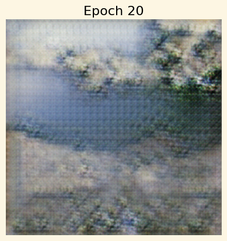

```python
# Prepare dataset
def load_and_preprocess_image(image_path):
    img = tf.io.read_file(image_path)
    img = tf.image.decode_jpeg(img, channels=3)
    img = tf.image.resize(img, [256, 256])
    img = (img - 127.5) / 127.5  # Normalize to [-1, 1]
    return img

# Load sample paths (in practice, use your dataset)
monet_paths = glob('./data/w5/monet_jpg/*.jpg')[:100]  # Sample
photo_paths = glob('./data/w5/photo_jpg/*.jpg')[:100]  # Sample

# Create datasets
monet_ds = tf.data.Dataset.from_tensor_slices(monet_paths).map(load_and_preprocess_image).batch(1)
photo_ds = tf.data.Dataset.from_tensor_slices(photo_paths).map(load_and_preprocess_image).batch(1)

# Initialize CycleGAN
cycle_gan = CycleGAN()

# Training loop
def train(cycle_gan, monet_ds, photo_ds, epochs=10):
    for epoch in range(epochs):
        start = time.time()

        # Reset metrics
        #cycle_gan.g_loss_metric.reset_states()
        #cycle_gan.d_loss_metric.reset_states()

        # Iterate through dataset
        for (monet, photo) in tf.data.Dataset.zip((monet_ds, photo_ds)):
            cycle_gan.train_step(photo, monet)

        # Print metrics
        print(f'Epoch {epoch + 1}, '
              f'Gen Loss: {cycle_gan.g_loss_metric.result():.4f}, '
              f'Disc Loss: {cycle_gan.d_loss_metric.result():.4f}, '
              f'Time: {time.time() - start:.2f}s')

        # Generate sample images every few epochs
        if (epoch + 1) % 5 == 0:
            for photo in photo_ds.take(1):
                generated_monet = cycle_gan.generate_images(cycle_gan.g_AB, photo)
                plt.imshow(generated_monet)
                plt.axis('off')
                plt.title(f'Epoch {epoch + 1}')
                plt.show()

# Start training
train(cycle_gan, monet_ds, photo_ds, epochs=20)
```

**Results**:

[output not shown]

```python
import os
import tensorflow as tf
import matplotlib.pyplot as plt
import numpy as np
from glob import glob

def generate_and_save_images(model, epoch, test_input, output_dir):
    """
    Generate and save images during training for monitoring progress.

    Args:
        model: Generator model (g_AB for photo→Monet)
        epoch: Current epoch number
        test_input: Batch of test images
        output_dir: Directory to save generated images
    """
    # Create directory if it doesn't exist
    os.makedirs(output_dir, exist_ok=True)

    # Generate images
    predictions = model(test_input, training=False)

    # Setup figure
    plt.figure(figsize=(10, 10))

    # Display and save images
    for i in range(min(predictions.shape[0], 6)):  # Display up to 6 images
        plt.subplot(2, 3, i+1)

        # Convert from [-1,1] to [0,1] and display
        img = predictions[i].numpy() * 0.5 + 0.5
        plt.imshow(img)
        plt.axis('off')

    plt.suptitle(f'Epoch {epoch}')
    plt.savefig(os.path.join(output_dir, f'epoch_{epoch:03d}.png'))
    plt.close()

# Example usage within a training loop
def train_with_image_generation(cycle_gan, monet_ds, photo_ds, epochs):
    # Create output directory
    output_dir = 'training_progress'
    os.makedirs(output_dir, exist_ok=True)

    # Get a fixed sample of photos for consistent comparison
    sample_photos = next(iter(photo_ds.take(1)))

    for epoch in range(epochs):
        start = time.time()

        # Reset metrics
        #cycle_gan.g_loss_metric.reset_states()
        #cycle_gan.d_loss_metric.reset_states()

        # Training loop
        for (monet, photo) in tf.data.Dataset.zip((monet_ds, photo_ds)):
            cycle_gan.train_step(photo, monet)

        # Print metrics
        print(f'Epoch {epoch + 1}, '
              f'Gen Loss: {cycle_gan.g_loss_metric.result():.4f}, '
              f'Disc Loss: {cycle_gan.d_loss_metric.result():.4f}, '
              f'Time: {time.time() - start:.2f}s')

        # Generate and save sample images every epoch
        generate_and_save_images(cycle_gan.g_AB, epoch + 1, sample_photos, output_dir)

        # Save model checkpoints every 5 epochs
        if (epoch + 1) % 5 == 0:
            cycle_gan.g_AB.save(f'monet_generator_epoch_{epoch+1}.h5')
```

## Full workflow example

```python
# Full workflow example
if __name__ == "__main__":
    # Load and prepare dataset
    def load_image(image_path):
        img = tf.io.read_file(image_path)
        img = tf.image.decode_jpeg(img, channels=3)
        img = tf.image.resize(img, [256, 256])
        img = (img - 127.5) / 127.5  # Normalize to [-1, 1]
        return img

    # Sample paths (in practice, use your full dataset)
    monet_paths = glob('./data/w5/monet_jpg/*.jpg')
    photo_paths = glob('./data/w5/photo_jpg/*.jpg')

    # Create datasets
    monet_ds = tf.data.Dataset.from_tensor_slices(monet_paths).map(load_image).batch(1)
    photo_ds = tf.data.Dataset.from_tensor_slices(photo_paths).map(load_image).batch(1)

    # Initialize and train CycleGAN
    cycle_gan = CycleGAN()
    train_with_image_generation(cycle_gan, monet_ds, photo_ds, epochs=30)

    # Generate final submission images
    def generate_submission_images(generator, photo_paths, num_images=7000):
        os.makedirs('submission_images', exist_ok=True)

        for i, path in enumerate(photo_paths[:num_images]):
            # Load and preprocess image
            img = load_image(path)
            img = tf.expand_dims(img, 0)  # Add batch dimension

            # Generate Monet-style image
            monet_img = generator(img, training=False)[0].numpy()
            monet_img = (monet_img * 127.5 + 127.5).astype(np.uint8)  # Convert to 0-255

            # Save image
            plt.imsave(f'submission_images/monet_{i:05d}.jpg', monet_img)

        # Zip the images
        import zipfile
        with zipfile.ZipFile('images.zip', 'w') as zipf:
            for file in glob('submission_images/*.jpg'):
                zipf.write(file)

        print(f"Generated {num_images} Monet-style images in images.zip")

    # Generate submission (using first 7000 photos)
    generate_submission_images(cycle_gan.g_AB, photo_paths, num_images=7000)
```

```
Epoch 1, Gen Loss: 7.9911, Disc Loss: 1.2863, Time: 624.63s
Epoch 2, Gen Loss: 7.7446, Disc Loss: 1.2256, Time: 671.03s
Epoch 3, Gen Loss: 7.9430, Disc Loss: 1.1148, Time: 795.31s
Epoch 4, Gen Loss: 8.1333, Disc Loss: 1.0357, Time: 791.26s
Epoch 5, Gen Loss: 8.3119, Disc Loss: 0.9851, Time: 671.86s
```

```
WARNING:absl:You are saving your model as an HDF5 file via `model.save()` or `keras.saving.save_model(model)`. This file format is considered legacy. We recommend using instead the native Keras format, e.g. `model.save('my_model.keras')` or `keras.saving.save_model(model, 'my_model.keras')`.
```

```
Epoch 6, Gen Loss: 8.4295, Disc Loss: 0.9524, Time: 626.97s
Epoch 7, Gen Loss: 8.5672, Disc Loss: 0.9172, Time: 574.60s
Epoch 8, Gen Loss: 8.7261, Disc Loss: 0.8838, Time: 634.77s
Epoch 9, Gen Loss: 8.8801, Disc Loss: 0.8503, Time: 757.64s
Epoch 10, Gen Loss: 9.0170, Disc Loss: 0.8216, Time: 735.00s
```

```
WARNING:absl:You are saving your model as an HDF5 file via `model.save()` or `keras.saving.save_model(model)`. This file format is considered legacy. We recommend using instead the native Keras format, e.g. `model.save('my_model.keras')` or `keras.saving.save_model(model, 'my_model.keras')`.
```

```
Epoch 11, Gen Loss: 9.1456, Disc Loss: 0.7972, Time: 573.78s
Epoch 12, Gen Loss: 9.2966, Disc Loss: 0.7724, Time: 581.45s
Epoch 13, Gen Loss: 9.4487, Disc Loss: 0.7477, Time: 572.88s
Epoch 14, Gen Loss: 9.5802, Disc Loss: 0.7267, Time: 543.56s
Epoch 15, Gen Loss: 9.7057, Disc Loss: 0.7126, Time: 529.36s
```

```
WARNING:absl:You are saving your model as an HDF5 file via `model.save()` or `keras.saving.save_model(model)`. This file format is considered legacy. We recommend using instead the native Keras format, e.g. `model.save('my_model.keras')` or `keras.saving.save_model(model, 'my_model.keras')`.
```

```
Epoch 16, Gen Loss: 9.8062, Disc Loss: 0.6969, Time: 520.40s
Epoch 17, Gen Loss: 9.9309, Disc Loss: 0.6821, Time: 530.92s
Epoch 18, Gen Loss: 10.0338, Disc Loss: 0.6687, Time: 523.39s
Epoch 19, Gen Loss: 10.1232, Disc Loss: 0.6591, Time: 535.11s
Epoch 20, Gen Loss: 10.2105, Disc Loss: 0.6474, Time: 539.16s
```

```
WARNING:absl:You are saving your model as an HDF5 file via `model.save()` or `keras.saving.save_model(model)`. This file format is considered legacy. We recommend using instead the native Keras format, e.g. `model.save('my_model.keras')` or `keras.saving.save_model(model, 'my_model.keras')`.
```

```
Epoch 21, Gen Loss: 10.2894, Disc Loss: 0.6374, Time: 527.08s
Epoch 22, Gen Loss: 10.3927, Disc Loss: 0.6268, Time: 523.69s
Epoch 23, Gen Loss: 10.4699, Disc Loss: 0.6192, Time: 532.90s
Epoch 24, Gen Loss: 10.5553, Disc Loss: 0.6107, Time: 521.80s
Epoch 25, Gen Loss: 10.6154, Disc Loss: 0.6040, Time: 534.30s
```

```
WARNING:absl:You are saving your model as an HDF5 file via `model.save()` or `keras.saving.save_model(model)`. This file format is considered legacy. We recommend using instead the native Keras format, e.g. `model.save('my_model.keras')` or `keras.saving.save_model(model, 'my_model.keras')`.
```

```
Epoch 26, Gen Loss: 10.6699, Disc Loss: 0.5981, Time: 576.44s
Epoch 27, Gen Loss: 10.7286, Disc Loss: 0.5916, Time: 538.76s
Epoch 28, Gen Loss: 10.7786, Disc Loss: 0.5870, Time: 560.09s
Epoch 29, Gen Loss: 10.8154, Disc Loss: 0.5830, Time: 653.43s
Epoch 30, Gen Loss: 10.8549, Disc Loss: 0.5779, Time: 736.25s
```

```
WARNING:absl:You are saving your model as an HDF5 file via `model.save()` or `keras.saving.save_model(model)`. This file format is considered legacy. We recommend using instead the native Keras format, e.g. `model.save('my_model.keras')` or `keras.saving.save_model(model, 'my_model.keras')`.
```

```
Generated 7000 Monet-style images in images.zip
```

## 5. Conclusion and Future Work

**Key Takeaways**:

**Challenges**:

- Limited Monet paintings made style learning difficult
- Balancing generator/discriminator training was tricky
- Achieving diverse outputs required careful tuning

**Future Improvements**:

1. Incorporate attention mechanisms to better capture brush strokes
2. Experiment with StyleGAN2 for higher resolution outputs
3. Use larger datasets with more artistic styles
4. Implement meta-learning to adapt to new styles faster
5. Add user control over style transfer degree